# 19. BusTime sign management

The Communications Department is responsible for determining what lines are shown on each of the electronic signs controlled by BusTime.

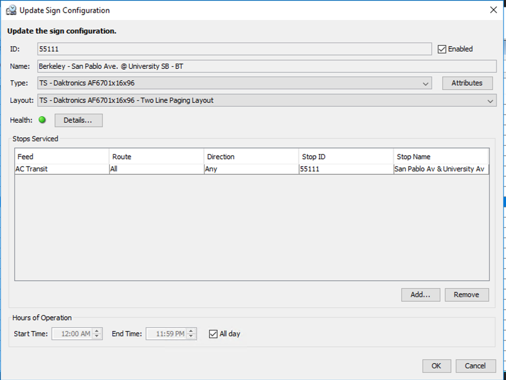

Nearly all the time, there’s not much to do here. Almost all signs are located at a stop, and should show all lines at that stop, and no other lines.

However…

Some electronic signs are at one stop, but very close to another stop as well, and both stops should be shown on the sign. Tempo center-platform stops are like this as well.

Some electronic signs are at stops where a no-locals-on-Transbay line stops. For example, lines G and L serve stops on San Pablo Avenue. Unless it’s changed recently, BusTime will show predictions for those even though one can’t board there. These lines should be omitted from the sign. Unfortunately, BusTime can only be set up to include particular lines and not exclude them, and so this causes errors when there are changes to lines.

It would be much better if BusTime could simply be told not to predict lines without boardings. That would avoid a lot of errors.